# 1. Business and data understanding

### Model Building & Validation using "Feature Selection" technique

## 5.2.4. SelectKBest

```python
mvdata.columns
```

```python
# declare X variables and y variable
X = mvdata[['num_critic_for_reviews', 'duration', 'director_facebook_likes',
       'actor_1_facebook_likes', 'gross', 'num_voted_users',
       'facenumber_in_poster', 'num_user_for_reviews', 'budget', 'title_year',
       'movie_facebook_likes', 'country_UK', 'country_USA',
       'country_other', 'other_actors_facebook_likes','content_rating_G', 'content_rating_NC-17', 'content_rating_PG',
       'content_rating_PG-13', 'content_rating_R']]
y = mvdata['imdb_binned']


X_KBest = SelectKBest(chi2, k=5).fit_transform(X, y)
#print(X_KBest)

# this will help you identify the column indexes (and names)
selector = SelectKBest(chi2, k=5).fit(X, y)
idxs_selected = selector.get_support(indices=True)
print(idxs_selected)
```

```
[ 3  4  5  8 10]
```

```
Accuracy Score: 0.8645054031587698
---------------Classification Report:-------------------
              precision    recall  f1-score   support

           0       0.25      0.25      0.25       108
           1       0.93      0.93      0.93      1095

    accuracy                           0.86      1203
   macro avg       0.59      0.59      0.59      1203
weighted avg       0.87      0.86      0.86      1203

AUC Score: 0.5875570776255707
---------------Confusion Matrix-------------------------
[[  27   81]
 [  82 1013]]
```

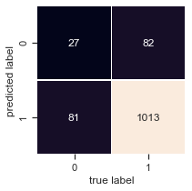

```python
# Build a decision tree model with those five best features ... Split validation:train (70%) and test sets (30%)
X_train, X_test, y_train, y_test =  train_test_split(X_KBest, y, test_size = 0.33, random_state = 0)

# Initialize decision tree
dt = DecisionTreeClassifier()

# Train the model
dt.fit(X_train,y_train)

#Predict Y values
Y_pred = dt.predict(X_test)

#build confusion materix
fig, ax = plt.subplots(figsize=(3,3))
mat = confusion_matrix(y_test, Y_pred)
sns.heatmap(mat.T, square=True, annot=True, fmt="d", cbar=False, linewidths=.5)
plt.xlabel('true label')
plt.ylabel('predicted label');

print("Accuracy Score:", metrics.accuracy_score(y_test, Y_pred))
print("---------------Classification Report:-------------------")
print(metrics.classification_report(y_test, Y_pred))
print("AUC Score:",metrics.roc_auc_score(y_test,Y_pred))
print("---------------Confusion Matrix-------------------------")
print(metrics.confusion_matrix(y_test, Y_pred))
```

```
Accuracy Score: 0.9113345521023766
---------------Classification Report:-------------------
              precision    recall  f1-score   support

           0       0.20      0.01      0.02        94
           1       0.91      1.00      0.95      1000

    accuracy                           0.91      1094
   macro avg       0.56      0.50      0.49      1094
weighted avg       0.85      0.91      0.87      1094

AUC Score: 0.5033191489361702
---------------Confusion Matrix-------------------------
[[  1  93]
 [  4 996]]
```

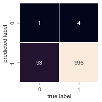

```python
# develop logistic regression model with X_KBest (only best five predictors or independent variables)
X_train, X_test, y_train, y_test = train_test_split(X_KBest, y, test_size=0.3, random_state=0)
lr = LogisticRegression()
lr.fit(X_train, y_train)

#Predict Y values
Y_pred = lr.predict(X_test)

#build confusion materix
fig, ax = plt.subplots(figsize=(3,3))
mat = confusion_matrix(y_test, Y_pred)
sns.heatmap(mat.T, square=True, annot=True, fmt="d", cbar=False, linewidths=.5)
plt.xlabel('true label')
plt.ylabel('predicted label');

print("Accuracy Score:", metrics.accuracy_score(y_test, Y_pred))
print("---------------Classification Report:-------------------")
print(metrics.classification_report(y_test, Y_pred))
print("AUC Score:",metrics.roc_auc_score(y_test,Y_pred))
print("---------------Confusion Matrix-------------------------")
print(metrics.confusion_matrix(y_test, Y_pred))
```

### 5.2.5. Recursive Feature Selection (RFE)

```python
model = LogisticRegression()
rfe = RFE(model, 5)  #returns five best attributes
rfe = rfe.fit(X, y)
# summarize the selection of the attributes
print((rfe.support_))
print((rfe.ranking_))
```

```
[False  True False False False False  True False False False False False
  True  True False False False False False  True]
[ 2  1  5  7 10  6  1  4 11  3  9 12  1  1  8 13 16 14 15  1]
```

```python
# Features sorted by their rank
pd.DataFrame({'feature':X.columns, 'importance':rfe.ranking_})
```

|  | feature | importance |
| --- | --- | --- |
| 0 | num_critic_for_reviews | 2 |
| 1 | duration | 1 |
| 2 | director_facebook_likes | 5 |
| 3 | actor_1_facebook_likes | 7 |
| 4 | gross | 10 |
| 5 | num_voted_users | 6 |
| 6 | facenumber_in_poster | 1 |
| 7 | num_user_for_reviews | 4 |
| 8 | budget | 11 |
| 9 | title_year | 3 |
| 10 | movie_facebook_likes | 9 |
| 11 | country_UK | 12 |
| 12 | country_USA | 1 |
| 13 | country_other | 1 |
| 14 | other_actors_facebook_likes | 8 |
| 15 | content_rating_G | 13 |
| 16 | content_rating_NC-17 | 16 |
| 17 | content_rating_PG | 14 |
| 18 | content_rating_PG-13 | 15 |
| 19 | content_rating_R | 1 |

```python
#here I select 5 most significant features only
X_logistic = mvdata[['duration', 'num_critic_for_reviews', 'title_year', 'num_user_for_reviews', 'director_facebook_likes']]
X_logistic.head(2)
```

|  | duration | num_critic_for_reviews | title_year | num_user_for_reviews | director_facebook_likes |
| --- | --- | --- | --- | --- | --- |
| 0 | 178.0 | 723.0 | 2009.0 | 3054.0 | 786.665875 |
| 1 | 169.0 | 302.0 | 2007.0 | 1238.0 | 563.000000 |

```
Accuracy Score: 0.8420615128844555
---------------Classification Report:-------------------
              precision    recall  f1-score   support

           0       0.17      0.19      0.18       108
           1       0.92      0.91      0.91      1095

    accuracy                           0.84      1203
   macro avg       0.54      0.55      0.55      1203
weighted avg       0.85      0.84      0.85      1203

AUC Score: 0.5501902587519025
---------------Confusion Matrix-------------------------
[[ 21  87]
 [103 992]]
```

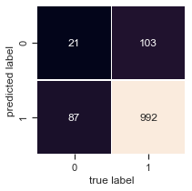

```python
# Build a decision tree model with those five best features ... Split validation:train (70%) and test sets (30%)
X_train, X_test, y_train, y_test =  train_test_split(X_logistic, y, test_size = 0.33, random_state = 0)

# Initialize decision tree
dt = DecisionTreeClassifier()

# Train the model
dt.fit(X_train,y_train)

#Predict Y values
Y_pred = dt.predict(X_test)

#build confusion materix
fig, ax = plt.subplots(figsize=(3,3))
mat = confusion_matrix(y_test, Y_pred)
sns.heatmap(mat.T, square=True, annot=True, fmt="d", cbar=False, linewidths=.5)
plt.xlabel('true label')
plt.ylabel('predicted label');

print("Accuracy Score:", metrics.accuracy_score(y_test, Y_pred))
print("---------------Classification Report:-------------------")
print(metrics.classification_report(y_test, Y_pred))
print("AUC Score:",metrics.roc_auc_score(y_test,Y_pred))
print("---------------Confusion Matrix-------------------------")
print(metrics.confusion_matrix(y_test, Y_pred))
```

```
Accuracy Score: 0.9140767824497258
---------------Classification Report:-------------------
              precision    recall  f1-score   support

           0       0.00      0.00      0.00        94
           1       0.91      1.00      0.96      1000

    accuracy                           0.91      1094
   macro avg       0.46      0.50      0.48      1094
weighted avg       0.84      0.91      0.87      1094

AUC Score: 0.5
---------------Confusion Matrix-------------------------
[[   0   94]
 [   0 1000]]
```

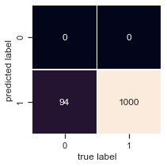

```python
# develop logistic regression model with X_KBest (only best five predictors or independent variables)
X_train, X_test, y_train, y_test = train_test_split(X_logistic, y, test_size=0.3, random_state=0)
lr = LogisticRegression()
lr.fit(X_train, y_train)

#Predict Y values
Y_pred = lr.predict(X_test)

#build confusion materix
fig, ax = plt.subplots(figsize=(3,3))
mat = confusion_matrix(y_test, Y_pred)
sns.heatmap(mat.T, square=True, annot=True, fmt="d", cbar=False, linewidths=.5)
plt.xlabel('true label')
plt.ylabel('predicted label');

print("Accuracy Score:", metrics.accuracy_score(y_test, Y_pred))
print("---------------Classification Report:-------------------")
print(metrics.classification_report(y_test, Y_pred))
print("AUC Score:",metrics.roc_auc_score(y_test,Y_pred))
print("---------------Confusion Matrix-------------------------")
print(metrics.confusion_matrix(y_test, Y_pred))
```

```python
import statsmodels.api as sm
logit_model=sm.Logit(y, X_logistic)
result=logit_model.fit()
print(result.summary())
```

```
Optimization terminated successfully.
         Current function value: 0.264130
         Iterations 8
                           Logit Regression Results
==============================================================================
Dep. Variable:            imdb_binned   No. Observations:                 3645
Model:                          Logit   Df Residuals:                     3640
Method:                           MLE   Df Model:                            4
Date:                Sun, 10 May 2020   Pseudo R-squ.:                  0.1323
Time:                        19:47:47   Log-Likelihood:                -962.75
converged:                       True   LL-Null:                       -1109.6
Covariance Type:            nonrobust   LLR p-value:                 2.582e-62
===========================================================================================
                              coef    std err          z      P>|z|      [0.025      0.975]
-------------------------------------------------------------------------------------------
duration                    0.0457      0.005      9.754      0.000       0.036       0.055
num_critic_for_reviews      0.0089      0.001      8.808      0.000       0.007       0.011
title_year                 -0.0016      0.000     -7.173      0.000      -0.002      -0.001
num_user_for_reviews       -0.0009      0.000     -4.049      0.000      -0.001      -0.000
director_facebook_likes     0.0001   6.58e-05      1.983      0.047    1.52e-06       0.000
===========================================================================================
```

```python
result.pred_table()
```

```
array([[0.000e+00, 3.310e+02],
       [2.000e+00, 3.312e+03]])
```

### 5.2.6. Feature Importance

Tree-based algorithms like randomforest offers feature importance.

```python
model_extra = ExtraTreesClassifier()
model_extra.fit(X, y)
print(model_extra.score(X, y))
```

```
1.0
```

```python
# display the relative importance of each attribute
print((model_extra.feature_importances_))
```

```
[0.09655424 0.08753205 0.06750083 0.06778653 0.08054046 0.0841048
 0.0625589  0.10087958 0.08271939 0.0776002  0.07933754 0.00257079
 0.00437638 0.00354944 0.06781726 0.00388241 0.00212101 0.0072554
 0.00889594 0.01241685]
```

```python
print("Features sorted by their rank:")
print(sorted(zip([round(x, 4) for x in model_extra.feature_importances_], X.columns)))
```

[output not shown]

```python
pd.DataFrame(model_extra.feature_importances_, index = X.columns,
                                    columns=['importance']).sort_values('importance', ascending=False)
```

|  | importance |
| --- | --- |
| num_user_for_reviews | 0.100880 |
| num_critic_for_reviews | 0.096554 |
| duration | 0.087532 |
| num_voted_users | 0.084105 |
| budget | 0.082719 |
| gross | 0.080540 |
| movie_facebook_likes | 0.079338 |
| title_year | 0.077600 |
| other_actors_facebook_likes | 0.067817 |
| actor_1_facebook_likes | 0.067787 |
| director_facebook_likes | 0.067501 |
| facenumber_in_poster | 0.062559 |
| content_rating_R | 0.012417 |
| content_rating_PG-13 | 0.008896 |
| content_rating_PG | 0.007255 |
| country_USA | 0.004376 |
| content_rating_G | 0.003882 |
| country_other | 0.003549 |
| country_UK | 0.002571 |
| content_rating_NC-17 | 0.002121 |

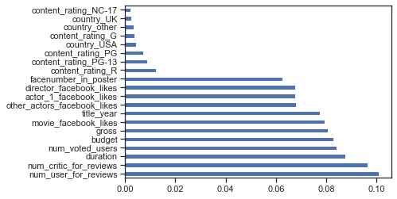

```python
pd.DataFrame(model_extra.feature_importances_, index = X.columns,
                                    columns=['importance']).sort_values('importance', ascending=False).plot(kind='barh',
                                                                                                            legend=None);
```

### 5.2.7 Support Vector Machine (SVM)

```python
# declare X variables and y variable
X = mvdata[['num_critic_for_reviews', 'duration', 'director_facebook_likes',
       'actor_1_facebook_likes', 'gross', 'num_voted_users',
       'facenumber_in_poster', 'num_user_for_reviews', 'budget', 'title_year',
       'movie_facebook_likes', 'country_UK', 'country_USA',
       'country_other', 'other_actors_facebook_likes','content_rating_G', 'content_rating_NC-17', 'content_rating_PG',
       'content_rating_PG-13', 'content_rating_R']]
y = mvdata['imdb_binned']

# split validation
X_train, X_test, y_train, y_test = train_test_split(X, y, test_size=0.3, random_state=0)
```

```
Accuracy Score: 0.9140767824497258
---------------Classification Report:-------------------
              precision    recall  f1-score   support

           0       0.00      0.00      0.00        94
           1       0.91      1.00      0.96      1000

    accuracy                           0.91      1094
   macro avg       0.46      0.50      0.48      1094
weighted avg       0.84      0.91      0.87      1094

AUC Score: 0.5
---------------Confusion Matrix-------------------------
[[   0   94]
 [   0 1000]]
```

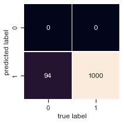

```python
svm = SVC(gamma='scale', probability=True)
svm.fit(X_train, y_train)

#Predict Y values
Y_pred = svm.predict(X_test)

#build confusion materix
fig, ax = plt.subplots(figsize=(3,3))
mat = confusion_matrix(y_test, Y_pred)
sns.heatmap(mat.T, square=True, annot=True, fmt="d", cbar=False, linewidths=.5)
plt.xlabel('true label')
plt.ylabel('predicted label');

print("Accuracy Score:", metrics.accuracy_score(y_test, Y_pred))
print("---------------Classification Report:-------------------")
print(metrics.classification_report(y_test, Y_pred))
print("AUC Score:",metrics.roc_auc_score(y_test,Y_pred))
print("---------------Confusion Matrix-------------------------")
print(metrics.confusion_matrix(y_test, Y_pred))
```

> **91.4% model accuracy**
> - **0.5 AUC score; AUC = Area Under Curve**

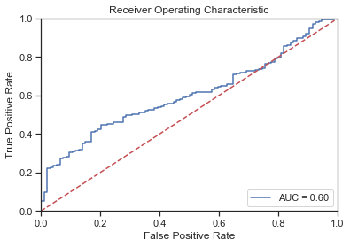

```python
# calculate the fpr and tpr for all thresholds of the classification
preds = svm.predict_proba(X_test)[:,1]
fpr, tpr, threshold = metrics.roc_curve(y_test, preds)
roc_auc = metrics.auc(fpr, tpr)

plt.title('Receiver Operating Characteristic')
plt.plot(fpr, tpr, 'b', label = 'AUC = %0.2f' % roc_auc)
plt.legend(loc = 'lower right')
plt.plot([0, 1], [0, 1],'r--')
plt.xlim([0, 1])
plt.ylim([0, 1])
plt.ylabel('True Positive Rate')
plt.xlabel('False Positive Rate')
plt.show()
```

### 5.2.8 GradientBoostingClassifier

```
Accuracy Score: 0.9186471663619744
---------------Classification Report:-------------------
              precision    recall  f1-score   support

           0       0.56      0.23      0.33        94
           1       0.93      0.98      0.96      1000

    accuracy                           0.92      1094
   macro avg       0.75      0.61      0.64      1094
weighted avg       0.90      0.92      0.90      1094

AUC Score: 0.6085212765957446
---------------Confusion Matrix-------------------------
[[ 22  72]
 [ 17 983]]
```

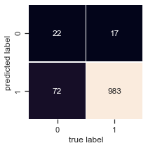

```python
# initialize
gb = GradientBoostingClassifier(n_estimators=100, random_state=0)

# fit the model
gb.fit(X_train, y_train)

#Predict Y values
Y_pred = gb.predict(X_test)

#build confusion materix
fig, ax = plt.subplots(figsize=(3,3))
mat = confusion_matrix(y_test, Y_pred)
sns.heatmap(mat.T, square=True, annot=True, fmt="d", cbar=False, linewidths=.5)
plt.xlabel('true label')
plt.ylabel('predicted label');

print("Accuracy Score:", metrics.accuracy_score(y_test, Y_pred))
print("---------------Classification Report:-------------------")
print(metrics.classification_report(y_test, Y_pred))
print("AUC Score:",metrics.roc_auc_score(y_test,Y_pred))
print("---------------Confusion Matrix-------------------------")
print(metrics.confusion_matrix(y_test, Y_pred))
```

> **91.86% model accuracy**
> - **0.60 AUC score; AUC = Area Under Curve**

```python
# 10-fold cross-validation
scores = cross_val_score(gb, X, y, scoring='accuracy', cv=10)
print(scores)
print(scores.mean())
```

```
[0.90710383 0.89041096 0.88767123 0.88493151 0.91483516 0.90934066
 0.90384615 0.8956044  0.91208791 0.90659341]
0.9012425216074442
```

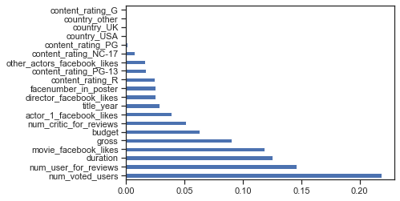

```python
pd.DataFrame(gb.feature_importances_, index = X.columns,
                                    columns=['importance']).sort_values('importance', ascending=False).plot(kind='barh',
                                                                                                            legend=None);
```

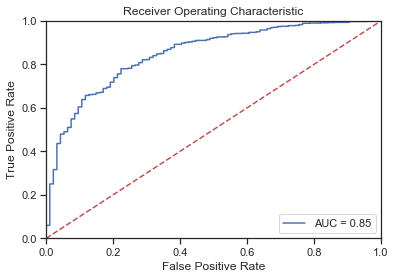

```python
# calculate the fpr and tpr for all thresholds of the classification
preds = gb.predict_proba(X_test)[:,1]
fpr, tpr, threshold = metrics.roc_curve(y_test, preds)
roc_auc = metrics.auc(fpr, tpr)

# method I: plt
import matplotlib.pyplot as plt
plt.title('Receiver Operating Characteristic')
plt.plot(fpr, tpr, 'b', label = 'AUC = %0.2f' % roc_auc)
plt.legend(loc = 'lower right')
plt.plot([0, 1], [0, 1],'r--')
plt.xlim([0, 1])
plt.ylim([0, 1])
plt.ylabel('True Positive Rate')
plt.xlabel('False Positive Rate')
plt.show()
```

### 5.2.9 Neural Network

```python
nn = MLPClassifier(solver='lbfgs', max_iter=500)
nn.fit(X_train, y_train)

#Predict Y values
Y_pred = nn.predict(X_test)

#build confusion materix
fig, ax = plt.subplots(figsize=(3,3))
mat = confusion_matrix(y_test, Y_pred)
sns.heatmap(mat.T, square=True, annot=True, fmt="d", cbar=False, linewidths=.5)
plt.xlabel('true label')
plt.ylabel('predicted label');

print("Accuracy Score:", metrics.accuracy_score(y_test, Y_pred))
print("---------------Classification Report:-------------------")
print(metrics.classification_report(y_test, Y_pred))
print("AUC Score:",metrics.roc_auc_score(y_test,Y_pred))
print("---------------Confusion Matrix-------------------------")
print(metrics.confusion_matrix(y_test, Y_pred))
```

[output not shown]

> **78.06% model accuracy**
> - **0.49 AUC score; AUC = Area Under Curve**

```python
# calculate the fpr and tpr for all thresholds of the classification
preds = nn.predict_proba(X_test)[:,1]
fpr, tpr, threshold = metrics.roc_curve(y_test, preds)
roc_auc = metrics.auc(fpr, tpr)

plt.title('Receiver Operating Characteristic')
plt.plot(fpr, tpr, 'b', label = 'AUC = %0.2f' % roc_auc)
plt.legend(loc = 'lower right')
plt.plot([0, 1], [0, 1],'r--')
plt.xlim([0, 1])
plt.ylim([0, 1])
plt.ylabel('True Positive Rate')
plt.xlabel('False Positive Rate')
plt.show()
```

[output not shown]

### Combined ROC

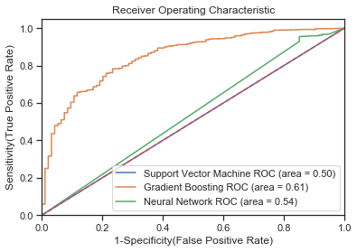

```python
#https://stackoverflow.com/questions/42894871/how-to-plot-multiple-roc-curves-in-one-plot-with-legend-and-auc-scores-in-python

plt.figure()

# Add the models to the list that you want to view on the ROC plot
models = [
{
    'label': 'Support Vector Machine',
    'model': SVC(gamma='auto', probability=True),
},
{
    'label': 'Gradient Boosting',
    'model': GradientBoostingClassifier(),
},
{
    'label': 'Neural Network',
    'model': MLPClassifier(solver='lbfgs', max_iter=500),
}
]

# Below for loop iterates through your models list
for m in models:
    model = m['model'] # select the model
    model.fit(X_train, y_train) # train the model
    #y_pred=model.predict(X_test) # predict the test data

    # Compute False postive rate, and True positive rate
    fpr, tpr, thresholds = metrics.roc_curve(y_test, model.predict_proba(X_test)[:,1])

    # Calculate Area under the curve to display on the plot
    auc = metrics.roc_auc_score(y_test,model.predict(X_test))

    # Now, plot the computed values
    plt.plot(fpr, tpr, label='%s ROC (area = %0.2f)' % (m['label'], auc))

# Custom settings for the plot
plt.plot([0, 1], [0, 1],'r--')
plt.xlim([0.0, 1.0])
plt.ylim([0.0, 1.05])
plt.xlabel('1-Specificity(False Positive Rate)')
plt.ylabel('Sensitivity(True Positive Rate)')
plt.title('Receiver Operating Characteristic')
plt.legend(loc="lower right")
plt.show()   # Display
```

- **GradientBoostingClassifier** is the best model for this dataset.

## 6. Clustering

• Analyze the data using K-means algorithm and Hierarchical clustering algorithm. You determine the optimal K value for K-means. This is exploratory data analysis and you need to report the movie “profiles” based on clustering analysis.

```python
df_X = mvdata.drop(['movie_title','imdb_binned','country_UK','country_USA','country_other','content_rating_G','content_rating_NC-17','content_rating_PG','content_rating_PG-13','content_rating_R'], axis=1)
df_X.head(1)
```

|  | num_critic_for_reviews | duration | director_facebook_likes | actor_1_facebook_likes | gross | num_voted_users | facenumber_in_poster | num_user_for_reviews | budget | title_year | imdb_score | movie_facebook_likes | other_actors_facebook_likes |
| --- | --- | --- | --- | --- | --- | --- | --- | --- | --- | --- | --- | --- | --- |
| 0 | 723.0 | 178.0 | 786.665875 | 1000.0 | 760505847.0 | 886204 | 1.383742 | 3054.0 | 237000000.0 | 2009.0 | 7.9 | 33000.0 | 1791.0 |

```python
df_X.info()
```

```
<class 'pandas.core.frame.DataFrame'>
Int64Index: 3645 entries, 0 to 5042
Data columns (total 13 columns):
num_critic_for_reviews         3645 non-null float64
duration                       3645 non-null float64
director_facebook_likes        3645 non-null float64
actor_1_facebook_likes         3645 non-null float64
gross                          3645 non-null float64
num_voted_users                3645 non-null int64
facenumber_in_poster           3645 non-null float64
num_user_for_reviews           3645 non-null float64
budget                         3645 non-null float64
title_year                     3645 non-null float64
imdb_score                     3645 non-null float64
movie_facebook_likes           3645 non-null float64
other_actors_facebook_likes    3645 non-null float64
dtypes: float64(12), int64(1)
memory usage: 558.7 KB
```

```python
#http://scikit-learn.org/stable/modules/generated/sklearn.cluster.KMeans.html
#four clusters

# clustering analysis with k = 4
k_means = KMeans(init='k-means++', n_clusters=4, random_state=0)
k_means.fit(df_X)
```

```
KMeans(algorithm='auto', copy_x=True, init='k-means++', max_iter=300,
       n_clusters=4, n_init=10, n_jobs=None, precompute_distances='auto',
       random_state=0, tol=0.0001, verbose=0)
```

Normalization is used to eliminate redundant data and ensures that good quality clusters are generated which can improve the efficiency of clustering algorithms. Data preprocessing techniques like cleaning and normalization to produce optimum quality clusters. In normalization the data to be analyzed is scaled to a specific range.

### Normalize data & Check variance again

```python
# normalize data and save as X
norm_X = (df_X - df_X.mean()) / (df_X.max() - df_X.min())
norm_X.head()
```

|  | num_critic_for_reviews | duration | director_facebook_likes | actor_1_facebook_likes | gross | num_voted_users | facenumber_in_poster | num_user_for_reviews | budget | title_year | imdb_score | movie_facebook_likes | other_actors_facebook_likes |
| --- | --- | --- | --- | --- | --- | --- | --- | --- | --- | --- | --- | --- | --- |
| 0 | 0.689073 | 0.234399 | -0.006134 | -0.010463 | 0.933277 | 0.464255 | -0.013694 | 0.539639 | 0.046287 | 0.139941 | 0.190672 | 0.056627 | -0.006953 |
| 1 | 0.170601 | 0.203683 | -0.015859 | 0.050474 | 0.340117 | 0.218665 | -0.013694 | 0.180675 | 0.061287 | 0.084385 | 0.086776 | -0.012416 | 0.023603 |
| 2 | 0.540059 | 0.132010 | -0.006134 | 0.005162 | 0.196357 | 0.103054 | -0.022831 | 0.132444 | 0.048191 | 0.306607 | 0.047815 | 0.205629 | -0.015933 |
| 3 | 0.799911 | 0.186618 | 0.916266 | 0.030162 | 0.522530 | 0.617020 | -0.013694 | 0.469863 | 0.049382 | 0.223274 | 0.268594 | 0.431997 | 0.313993 |
| 5 | 0.367645 | 0.077403 | -0.019685 | -0.011026 | 0.029343 | 0.065377 | -0.022831 | 0.081841 | 0.052644 | 0.223274 | 0.021841 | 0.030838 | -0.011519 |

```python
norm_X.var()
```

```
num_critic_for_reviews         0.023056
duration                       0.005441
director_facebook_likes        0.017425
actor_1_facebook_likes         0.000599
gross                          0.008210
num_voted_users                0.007840
facenumber_in_poster           0.001726
num_user_for_reviews           0.006399
budget                         0.000673
title_year                     0.045469
imdb_score                     0.018629
movie_facebook_likes           0.003348
other_actors_facebook_likes    0.001731
dtype: float64
```

Varinance of every column is now between 0 and 1

### Clustering analysis using K-means (k = 2): with normalized data

```python
#http://scikit-learn.org/stable/modules/generated/sklearn.cluster.KMeans.html
#four clusters
k_means = KMeans(init='k-means++', n_clusters=2, random_state=0)
k_means.fit(norm_X)
```

```
KMeans(algorithm='auto', copy_x=True, init='k-means++', max_iter=300,
       n_clusters=2, n_init=10, n_jobs=None, precompute_distances='auto',
       random_state=0, tol=0.0001, verbose=0)
```

```python
#cluster centroids or centers
print(k_means.cluster_centers_)
print(k_means.labels_)
```

```
[[-0.09131684 -0.00559383 -0.00378211 -0.00318174 -0.01631138 -0.02198005
  -0.00325017 -0.01702993 -0.00184956 -0.16619143 -0.02104602 -0.02105955
  -0.00682389]
 [ 0.0874425   0.00535649  0.00362164  0.00304674  0.01561933  0.02104749
   0.00311228  0.0163074   0.00177109  0.15914034  0.02015309  0.02016604
   0.00653437]]
[1 1 1 ... 0 1 0]
```

```python
#To add cluster label into the dataset as a column
mvdata = mvdata.reset_index(drop=True)
#df_cluster = df_cluster.reset_index(drop=True)

df_cluster = pd.DataFrame(k_means.labels_, columns = ['cluster'])
df_clustered = mvdata.join(df_cluster)
df_clustered.head(2)
```

|  | num_critic_for_reviews | duration | director_facebook_likes | actor_1_facebook_likes | gross | movie_title | num_voted_users | facenumber_in_poster | num_user_for_reviews | budget | ... | country_USA | country_other | other_actors_facebook_likes | imdb_binned | content_rating_G | content_rating_NC-17 | content_rating_PG | content_rating_PG-13 | content_rating_R | cluster |
| --- | --- | --- | --- | --- | --- | --- | --- | --- | --- | --- | --- | --- | --- | --- | --- | --- | --- | --- | --- | --- | --- |
| 0 | 723.0 | 178.0 | 786.665875 | 1000.0 | 760505847.0 | Avatar | 886204 | 1.383742 | 3054.0 | 237000000.0 | ... | 1 | 0 | 1791.0 | 1 | 0 | 0 | 0 | 1 | 0 | 1 |
| 1 | 302.0 | 169.0 | 563.000000 | 40000.0 | 309404152.0 | Pirates of the Caribbean: At World's End | 471220 | 1.383742 | 1238.0 | 300000000.0 | ... | 1 | 0 | 6000.0 | 1 | 0 | 0 | 0 | 1 | 0 | 1 |

2 rows × 24 columns

```python
df_clustered.groupby('cluster').mean()
```

| cluster | num_critic_for_reviews | duration | director_facebook_likes | actor_1_facebook_likes | gross | num_voted_users | facenumber_in_poster | num_user_for_reviews | budget | title_year | ... | movie_facebook_likes | country_UK | country_USA | country_other | other_actors_facebook_likes | content_rating_G | content_rating_NC-17 | content_rating_PG | content_rating_PG-13 | content_rating_R |
| --- | --- | --- | --- | --- | --- | --- | --- | --- | --- | --- | --- | --- | --- | --- | --- | --- | --- | --- | --- | --- | --- |
| 0 | 89.323051 | 107.681997 | 840.74356 | 5660.279424 | 3.833853e+07 | 64592.588334 | 1.822375 | 237.810993 | 3.482774e+07 | 1997.979248 | ... | 5888.221903 | 0.075154 | 0.81548 | 0.109366 | 1808.772396 | 0.037016 | 0.002243 | 0.160404 | 0.311834 | 0.488503 |
| 1 | 234.475636 | 110.890440 | 1011.01490 | 9646.494974 | 6.262202e+07 | 137298.034909 | 2.089598 | 406.464554 | 5.003448e+07 | 2009.691192 | ... | 20275.498519 | 0.083244 | 0.77927 | 0.137487 | 3648.819944 | 0.035446 | 0.000537 | 0.139098 | 0.389366 | 0.435553 |

2 rows × 21 columns

```python
df_clustered.groupby(['cluster']).count()
#which cluster is the largest
```

| cluster | num_critic_for_reviews | duration | director_facebook_likes | actor_1_facebook_likes | gross | movie_title | num_voted_users | facenumber_in_poster | num_user_for_reviews | budget | ... | country_UK | country_USA | country_other | other_actors_facebook_likes | imdb_binned | content_rating_G | content_rating_NC-17 | content_rating_PG | content_rating_PG-13 | content_rating_R |
| --- | --- | --- | --- | --- | --- | --- | --- | --- | --- | --- | --- | --- | --- | --- | --- | --- | --- | --- | --- | --- | --- |
| 0 | 1783 | 1783 | 1783 | 1783 | 1783 | 1783 | 1783 | 1783 | 1783 | 1783 | ... | 1783 | 1783 | 1783 | 1783 | 1783 | 1783 | 1783 | 1783 | 1783 | 1783 |
| 1 | 1862 | 1862 | 1862 | 1862 | 1862 | 1862 | 1862 | 1862 | 1862 | 1862 | ... | 1862 | 1862 | 1862 | 1862 | 1862 | 1862 | 1862 | 1862 | 1862 | 1862 |

2 rows × 23 columns

A modified k means algorithm is proposed which provides a solution for automatic initialization of centroids and performance is enhanced using normalization.

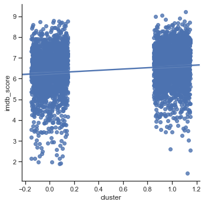

```python
sns.lmplot("cluster", "imdb_score", df_clustered, x_jitter=.15, y_jitter=.15)
```

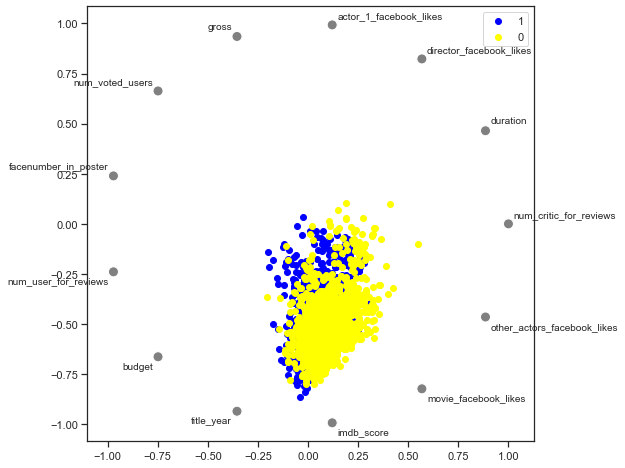

```python
df_plot = df_clustered.drop(['movie_title','imdb_binned','country_UK','country_USA','country_other','content_rating_G','content_rating_NC-17','content_rating_PG','content_rating_PG-13','content_rating_R'], axis=1)
df_plot.head(2)
#plot the normalized data points per each cluster
from pandas.plotting import radviz
plt.figure(figsize=(8,8))
radviz(df_plot, "cluster" ,color=['blue', 'yellow'])
```

### Clustering analysis using AgglomerativeClustering (# of clusters = 2)

```python
np.random.seed(1) # setting random seed to get the same results each time.

agg= AgglomerativeClustering(n_clusters=2, linkage='ward').fit(norm_X)
agg.labels_
```

```
array([0, 0, 0, ..., 1, 0, 0], dtype=int64)
```

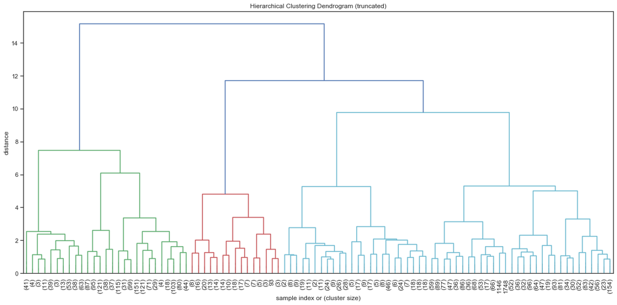

```python
plt.figure(figsize=(16,8))

plt.title('Hierarchical Clustering Dendrogram (truncated)')
plt.xlabel('sample index or (cluster size)')
plt.ylabel('distance')

linkage_matrix = ward(norm_X)
dendrogram(linkage_matrix,
           truncate_mode='lastp',  # show only the last p merged clusters
           p=96,  # show only the last p merged clusters
           leaf_rotation=90.,
           leaf_font_size=12.,
           show_contracted=True,  # to get a distribution impression in truncated branches
           orientation="top",)
plt.tight_layout() # fixes margins
```

# Storytelling

- One self-imposed limitation in our approach is that we allowed ourselves only to consider as input features those which are known about a movie pre-release. For example, we could surely have achieved higher success rates if we considered the awards that a movie would go on to win, but this did not seem very insightful. Our dataset was also heavily skewed to movies post 1980, as many before that do not have accurate financial data.

**Some key findings from this analysis:**

- Movie facebook likes Pattren seems to be increasing with score, that means movie with high imdb score tend to have high face book likes too.
- Movies with high Facebook likes tend to have higher imdb score. But the score for movie with low Facebook likes vary in a very wide range.
- Movie num_voted_users seems to be increasing with score, that means movie with high imdb score tend to have high face book likes too.
- director_facebook_likes, actor_1_facebook_likes, num_voted_users, num_user_for_reviews, budget are nearly constant for top 20 movies and doesn't seem to have great impact on gross of movie.
- Budget of the movie doesn't seem to play important role in success of movie, because gross is almost same for all the movies made with various range of budgets.
- Telugu is the top language with highest imdb average score, which is quite astonishing to know because thats my mother tounge.

Below are the best Machine Learning models that are trained in Regression, Classification and Clustering methods.

- **Multiple Regression model taking below important X features** is the best model with **low mean square error: 0.69** and **high variance or r-squared: 0.37**
  - num_critic_for_reviews, duration, facenumber_in_poster, title_year, country_UK, country_USA, country_other, content_rating_G, content_rating_NC-17, content_rating_PG, content_rating_PG-13, content_rating_R
- GradientBoostingClassifier is the best classification model in classifying a movie a success/failure given the features with

  > **91.86% model accuracy** and **0.60 AUC score**
- K-means algorithm is the good proposed solution for automatic initialization of centroids and increased performance using normalization.

While a near-perfect predictor some day would be a machine learning triumph, it could also lead to an overly algorithmic approach to movie planning. Studios may be less willing to take risks, and outliers are often some of the most exciting products of Hollywood.

Citations: http://cs229.stanford.edu/proj2013/EricsonGrodman-APredictorForMovieSuccess.pdf